# Tidyquant Library

Ali Tahsili

13/11/2021

# Discription

## Features of Tidyquant

- A few core functions with a lot of power
- Integrates the quantitative analysis functionality of zoo, xts, quantmod, TTR, and PerformanceAnalytics
- Designed for modeling and scaling analyses using the tidyverse tools in R for Data Science
- Implements ggplot2 functionality for beautiful and meaningful financial visualizations

## Core Functions

- **tq_get()**: Getting Financial Data from the web
- **tq_transmute()** and **tq_mutate()**: Manipulating Financial Data
- **tq_performance()** and **tq_portfolio()**: Performance Analysis and Portfolio Analysis

# tq_get()

The **tq_get()** function is used to collect data by changing the get argument. The data sources:

1- Yahoo Finance - Daily stock data

2- FRED - Economic data

3- Quandl - Economic, Energy, & Financial Data API

4- Tiingo - Financial API with sub-daily stock data and crypto-currency

5- Alpha Vantage - Financial API with sub-daily, ForEx, and crypto-currency data

6- Bloomberg - Financial API. Paid account is required.

```r
tq_get_options()
```

```
##  [1] "stock.prices"       "stock.prices.japan" "dividends"
##  [4] "splits"             "economic.data"      "quandl"
##  [7] "quandl.datatable"   "tiingo"             "tiingo.iex"
## [10] "tiingo.crypto"      "alphavantager"      "alphavantage"
## [13] "rblpapi"
```

We can use **tq_get()** in the following form:

**tq_get(x, get = “stock.prices”, from = “date”, to = “date”, …)**

## Collecting Data from Yahoo Finance

```r
(Stocks_Price_Data <- tq_get(c("GOOG", "AMZN"),
      get  = "stock.prices",
      from = "2017-01-01",
      to   = "2018-01-01"))
```

```
## # A tibble: 502 × 8
##    symbol date        open  high   low close  volume adjusted
##    <chr>  <date>     <dbl> <dbl> <dbl> <dbl>   <dbl>    <dbl>
##  1 GOOG   2017-01-03  779.  790.  776.  786. 1657300     786.
##  2 GOOG   2017-01-04  788.  791.  783.  787. 1073000     787.
##  3 GOOG   2017-01-05  786.  794.  785.  794. 1335200     794.
##  4 GOOG   2017-01-06  795.  808.  792.  806. 1640200     806.
##  5 GOOG   2017-01-09  806.  810.  803.  807. 1274600     807.
##  6 GOOG   2017-01-10  808.  809.  804.  805. 1176800     805.
##  7 GOOG   2017-01-11  805   808.  801.  808. 1065900     808.
##  8 GOOG   2017-01-12  807.  807.  799.  806. 1353100     806.
##  9 GOOG   2017-01-13  807.  811.  807.  808. 1099200     808.
## 10 GOOG   2017-01-17  807.  807.  800.  805. 1362100     805.
## # … with 492 more rows
```

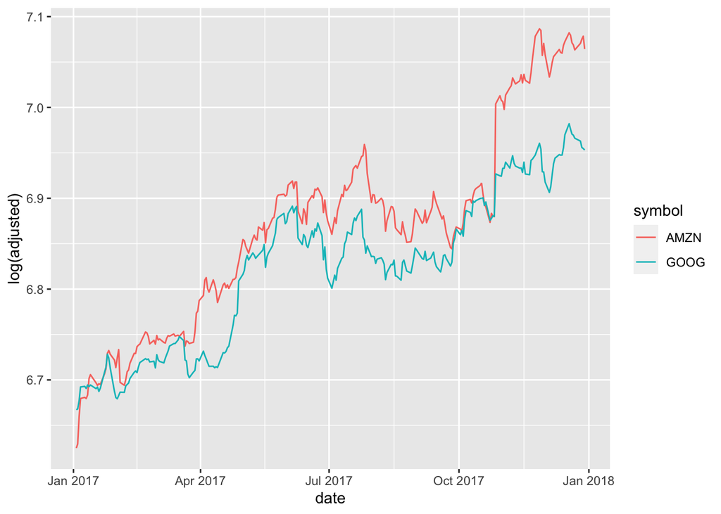

```r
Stocks_Price_Data %>%
  ggplot() +
  aes(date, log(adjusted), color = symbol) +
  geom_line()
```

## Candlestick Chart

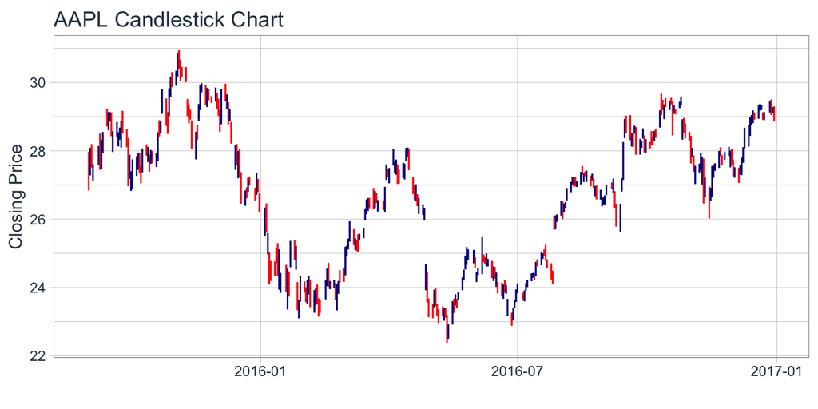

```r
# Get AAPL and AMZN Stock Prices
AAPL <- tq_get("AAPL", get = "stock.prices", from = "2015-09-01", to = "2016-12-31")

AAPL %>%
    ggplot(aes(x = date, y = close)) +
    geom_candlestick(aes(open = open, high = high, low = low, close = close)) +
    labs(title = "AAPL Candlestick Chart", y = "Closing Price", x = "") +
    theme_tq()
```

## Collecting Data from FRED

A wealth of economic data can be extracted from the Federal Reserve Economic Data (FRED) database. The FRED contains over 10K data sets that are free to use. The WTI Crude Oil Prices are shown below.

```r
tq_get("DCOILWTICO", get = "economic.data")
```

```
## # A tibble: 2,831 × 3
##    symbol     date       price
##    <chr>      <date>     <dbl>
##  1 DCOILWTICO 2011-01-03  91.6
##  2 DCOILWTICO 2011-01-04  89.4
##  3 DCOILWTICO 2011-01-05  90.3
##  4 DCOILWTICO 2011-01-06  88.4
##  5 DCOILWTICO 2011-01-07  88.1
##  6 DCOILWTICO 2011-01-10  89.2
##  7 DCOILWTICO 2011-01-11  91.1
##  8 DCOILWTICO 2011-01-12  91.8
##  9 DCOILWTICO 2011-01-13  91.4
## 10 DCOILWTICO 2011-01-14  91.5
## # … with 2,821 more rows
```

## Collecting Data from quandl

The following uses get = “quandl” and the “WIKI” database to download daily stock prices for FB and AAPL in 2016. The output is a tidy data frame.

```r
# quandl_api_key("<your-api-key>")
c("WIKI/FB", "WIKI/AAPL") %>%
    tq_get(get  = "quandl",
           from = "2016-01-01",
           to   = "2016-12-31")
```

```
## # A tibble: 504 × 14
##    symbol  date        open  high   low close   volume ex.dividend split.ratio
##    <chr>   <date>     <dbl> <dbl> <dbl> <dbl>    <dbl>       <dbl>       <dbl>
##  1 WIKI/FB 2016-01-04 102.  102.   99.8 102.  37912403           0           1
##  2 WIKI/FB 2016-01-05 103.  104.  102.  103.  23258238           0           1
##  3 WIKI/FB 2016-01-06 101.  104.  101.  103.  25096183           0           1
##  4 WIKI/FB 2016-01-07 100.  101.   97.3  97.9 45172906           0           1
##  5 WIKI/FB 2016-01-08  99.9 100.   97.0  97.3 35402298           0           1
##  6 WIKI/FB 2016-01-11  97.9  98.6  95.4  97.5 29932385           0           1
##  7 WIKI/FB 2016-01-12  99   100.   97.6  99.4 28395390           0           1
##  8 WIKI/FB 2016-01-13 101.  101.   95.2  95.4 33410553           0           1
##  9 WIKI/FB 2016-01-14  95.8  98.9  92.4  98.4 48658623           0           1
## 10 WIKI/FB 2016-01-15  94.0  96.4  93.5  95.0 46132781           0           1
## # … with 494 more rows, and 5 more variables: adj.open <dbl>, adj.high <dbl>,
## #   adj.low <dbl>, adj.close <dbl>, adj.volume <dbl>
```

## Indexes and Exchanges

There are specifically two functions for indexes and exchanges:

**tq_index()** consists of 5 indexes.

```r
tq_index_options()
```

```
## [1] "DOW"       "DOWGLOBAL" "SP400"     "SP500"     "SP600"
```

**tq_exchange()** consists of 3 exchanges.

```r
tq_exchange_options()
```

```
## [1] "AMEX"   "NASDAQ" "NYSE"
```

## Example for index

```r
tq_index("SP500")
```

```
## # A tibble: 505 × 8
##    symbol company    identifier sedol  weight sector  shares_held local_currency
##    <chr>  <chr>      <chr>      <chr>   <dbl> <chr>         <dbl> <chr>
##  1 MSFT   Microsoft… 59491810   25881… 0.0633 Inform…    80342500 USD
##  2 AAPL   Apple Inc. 03783310   20462… 0.0589 Inform…   167889400 USD
##  3 AMZN   Amazon.co… 02313510   20000… 0.0383 Consum…     4656410 USD
##  4 GOOGL  Alphabet … 02079K30   BYVY8… 0.0223 Commun…     3218899 USD
##  5 TSLA   Tesla Inc  88160R10   B616C… 0.0219 Consum…     8675106 USD
##  6 GOOG   Alphabet … 02079K10   BYY88… 0.0210 Commun…     3012175 USD
##  7 FB     Meta Plat… 30303M10   B7TL8… 0.0198 Commun…    25485518 USD
##  8 NVDA   NVIDIA Co… 67066G10   23795… 0.0192 Inform…    26642196 USD
##  9 BRK.B  Berkshire… 08467070   20733… 0.0134 Financ…    19817750 USD
## 10 JPM    JPMorgan … 46625H10   21903… 0.0127 Financ…    31948772 USD
## # … with 495 more rows
```

## Example for exchange

```r
tq_exchange("NASDAQ")
```

```
## # A tibble: 4,715 × 7
##    symbol company      last.sale.price  market.cap country ipo.year industry
##    <chr>  <chr>                  <dbl>       <dbl> <chr>      <int> <chr>
##  1 AACG   ATA Creativ…            2.21     6.93e 7 China         NA "Service to…
##  2 AACI   Armada Acqu…            9.75     2.02e 8 United…     2021 ""
##  3 AACIU  Armada Acqu…           10.0      0       United…     2021 ""
##  4 AACIW  Armada Acqu…            0.5      0       United…     2021 ""
##  5 AADI   Aadi Biosci…           22.2      4.62e 8 United…       NA "Biotechnol…
##  6 AAL    American Ai…           20.3      1.31e10 United…       NA "Air Freigh…
##  7 AAME   Atlantic Am…            4.25     8.67e 7 United…       NA "Life Insur…
##  8 AAOI   Applied Opt…            6.08     1.66e 8 United…     2013 "Semiconduc…
##  9 AAON   AAON Inc. C…           77.5      4.06e 9 United…       NA "Industrial…
## 10 AAPL   Apple Inc. …          150.       2.60e12 United…     1980 "Computer M…
## # … with 4,705 more rows
```

# tq_transmute() and tq_mutate()

Integration for many financial functions from xts, zoo, quantmod,TTR and PerformanceAnalytics packages.

- **tq_mutate()** is used to add a column to the data frame.
- **tq_transmute()** is used to return a new data frame which is necessary for periodicity changes.

## Compatibility

Mutating functions enable the xts/zoo, quantmod and TTR functions to shine. To see tidyquant function compatibility we can use **tq_transmute_fun_options()** which returns a list the compatible mutate functions by each package. We’ll discuss these options by package briefly.

```r
tq_transmute_fun_options() %>% str()
```

```
## List of 5
##  $ zoo                 : chr [1:14] "rollapply" "rollapplyr" "rollmax" "rollmax.default" ...
##  $ xts                 : chr [1:27] "apply.daily" "apply.monthly" "apply.quarterly" "apply.weekly" ...
##  $ quantmod            : chr [1:25] "allReturns" "annualReturn" "ClCl" "dailyReturn" ...
##  $ TTR                 : chr [1:63] "adjRatios" "ADX" "ALMA" "aroon" ...
##  $ PerformanceAnalytics: chr [1:7] "Return.annualized" "Return.annualized.excess" "Return.clean" "Return.cumulative" ...
```

## zoo Functionality

```r
# Get zoo functions that work with tq_transmute and tq_mutate
tq_transmute_fun_options()$zoo
```

```
##  [1] "rollapply"          "rollapplyr"         "rollmax"
##  [4] "rollmax.default"    "rollmaxr"           "rollmean"
##  [7] "rollmean.default"   "rollmeanr"          "rollmedian"
## [10] "rollmedian.default" "rollmedianr"        "rollsum"
## [13] "rollsum.default"    "rollsumr"
```

## xts Functionality

```r
# Get xts functions that work with tq_transmute and tq_mutate
tq_transmute_fun_options()$xts
```

```
##  [1] "apply.daily"     "apply.monthly"   "apply.quarterly" "apply.weekly"
##  [5] "apply.yearly"    "diff.xts"        "lag.xts"         "period.apply"
##  [9] "period.max"      "period.min"      "period.prod"     "period.sum"
## [13] "periodicity"     "to_period"       "to.daily"        "to.hourly"
## [17] "to.minutes"      "to.minutes10"    "to.minutes15"    "to.minutes3"
## [21] "to.minutes30"    "to.minutes5"     "to.monthly"      "to.period"
## [25] "to.quarterly"    "to.weekly"       "to.yearly"
```

## quantmod Functionality

```r
# Get quantmod functions that work with tq_transmute and tq_mutate
tq_transmute_fun_options()$quantmod
```

```
##  [1] "allReturns"      "annualReturn"    "ClCl"            "dailyReturn"
##  [5] "Delt"            "HiCl"            "Lag"             "LoCl"
##  [9] "LoHi"            "monthlyReturn"   "Next"            "OpCl"
## [13] "OpHi"            "OpLo"            "OpOp"            "periodReturn"
## [17] "quarterlyReturn" "seriesAccel"     "seriesDecel"     "seriesDecr"
## [21] "seriesHi"        "seriesIncr"      "seriesLo"        "weeklyReturn"
## [25] "yearlyReturn"
```

Note: we can do the same for TTR and PerformanceAnalytics functions.

We can use **tq_mutate()** and **tq_transmute()** in the following forms:

- **tq_mutate(data, select = NULL, mutate_fun, col_rename = NULL, ohlc_fun = NULL, …)**
- **tq_transmute(data, select = NULL, mutate_fun, col_rename = NULL, ohlc_fun = NULL, …)**

## Two examples using quantmod and xts

We’ll go through two examples, but first let’s get some data. The **FANG** data set will be used which consists of stock prices for FB, AMZN, NFLX, and GOOG from the beginning of 2013 to the end of 2016.

```r
data("FANG")

FANG
```

```
## # A tibble: 4,032 × 8
##    symbol date        open  high   low close    volume adjusted
##    <chr>  <date>     <dbl> <dbl> <dbl> <dbl>     <dbl>    <dbl>
##  1 FB     2013-01-02  27.4  28.2  27.4  28    69846400     28
##  2 FB     2013-01-03  27.9  28.5  27.6  27.8  63140600     27.8
##  3 FB     2013-01-04  28.0  28.9  27.8  28.8  72715400     28.8
##  4 FB     2013-01-07  28.7  29.8  28.6  29.4  83781800     29.4
##  5 FB     2013-01-08  29.5  29.6  28.9  29.1  45871300     29.1
##  6 FB     2013-01-09  29.7  30.6  29.5  30.6 104787700     30.6
##  7 FB     2013-01-10  30.6  31.5  30.3  31.3  95316400     31.3
##  8 FB     2013-01-11  31.3  32.0  31.1  31.7  89598000     31.7
##  9 FB     2013-01-14  32.1  32.2  30.6  31.0  98892800     31.0
## 10 FB     2013-01-15  30.6  31.7  29.9  30.1 173242600     30.1
## # … with 4,022 more rows
```

### Example 1: (quantmod::periodReturn() function)

Our goal is to convert prices to returns

```r
FANG_annual_returns <- FANG %>%
    group_by(symbol) %>%
    tq_transmute(select     = adjusted,
                 mutate_fun = periodReturn,
                 period     = "yearly",
                 type       = "arithmetic")
FANG_annual_returns %>% head(5)
```

```
## # A tibble: 5 × 3
## # Groups:   symbol [2]
##   symbol date       yearly.returns
##   <chr>  <date>              <dbl>
## 1 FB     2013-12-31         0.952
## 2 FB     2014-12-31         0.428
## 3 FB     2015-12-31         0.341
## 4 FB     2016-12-30         0.0993
## 5 AMZN   2013-12-31         0.550
```

## Countinue

```r
FANG_yearly_returns <- FANG_annual_returns %>%
    ggplot(aes(x = date, y = yearly.returns, fill = symbol)) +
    geom_col() +
    geom_hline(yintercept = 0, color = palette_light()[[1]]) +
    scale_y_continuous(labels = scales::percent) +
    labs(title = "FANG: Annual Returns",
         subtitle = "Get annual returns quickly with tq_transmute!",
         y = "Annual Returns", x = "") +
    facet_wrap(~ symbol, ncol = 2, scales = "free_y") +
    theme_tq() +
    scale_fill_tq()
```

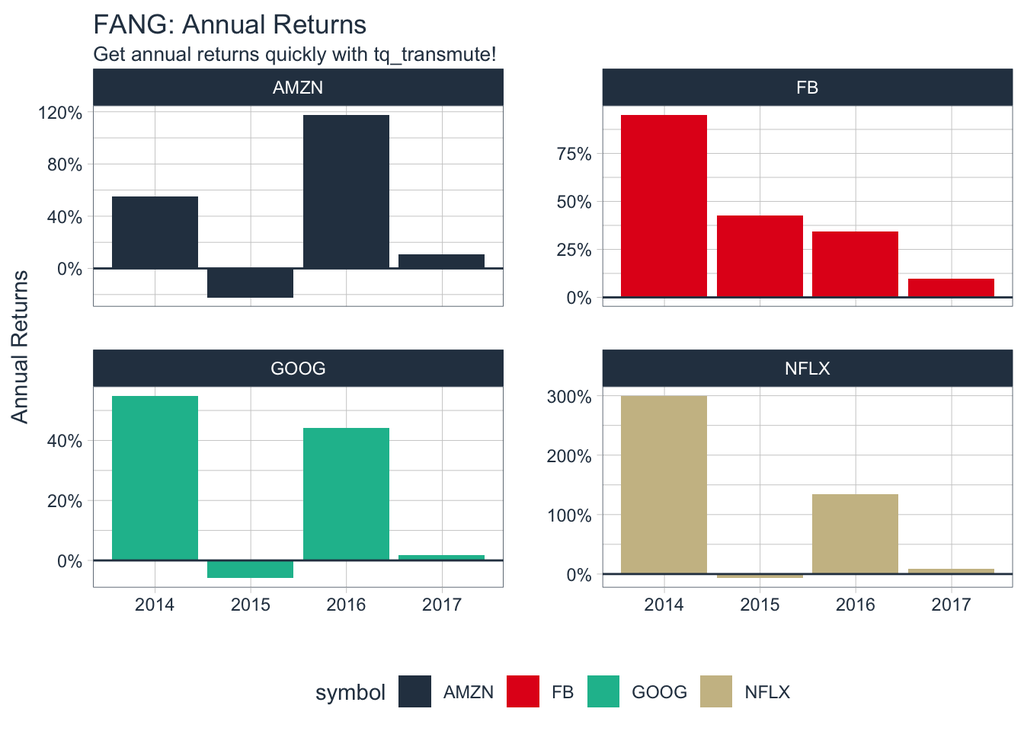

```r
FANG_yearly_returns
```

### Example 2 (xts::to.period function)

Our goal is to change the periodicity from daily to monthly

```r
FANG %>%
    group_by(symbol) %>%
    tq_transmute(select     = open:volume,
                 mutate_fun = to.period,
                 period     = "months") %>% head(5)
```

```
## # A tibble: 5 × 7
## # Groups:   symbol [1]
##   symbol date        open  high   low close    volume
##   <chr>  <date>     <dbl> <dbl> <dbl> <dbl>     <dbl>
## 1 FB     2013-01-31  29.2  31.5  28.7  31.0 190744900
## 2 FB     2013-02-28  26.8  27.3  26.3  27.2  83027800
## 3 FB     2013-03-28  26.1  26.2  25.5  25.6  28585700
## 4 FB     2013-04-30  27.1  27.8  27.0  27.8  36245700
## 5 FB     2013-05-31  24.6  25.0  24.3  24.4  35925000
```

A common usage case is to reduce the number of points to smooth time series plots. Let’s check out difference between daily and monthly plots.

### Without Periodicity Aggregation

```r
FANG_daily <- FANG %>%
    group_by(symbol)

FANG.plot.daily <- FANG_daily %>%
    ggplot(aes(x = date, y = adjusted, color = symbol)) +
    geom_line(size = 1) +
    labs(title = "Daily Stock Prices",
         x = "", y = "Adjusted Prices", color = "") +
    facet_wrap(~ symbol, ncol = 2, scales = "free_y") +
    scale_y_continuous(labels = scales::dollar) +
    theme_tq() +
    scale_color_tq()
```

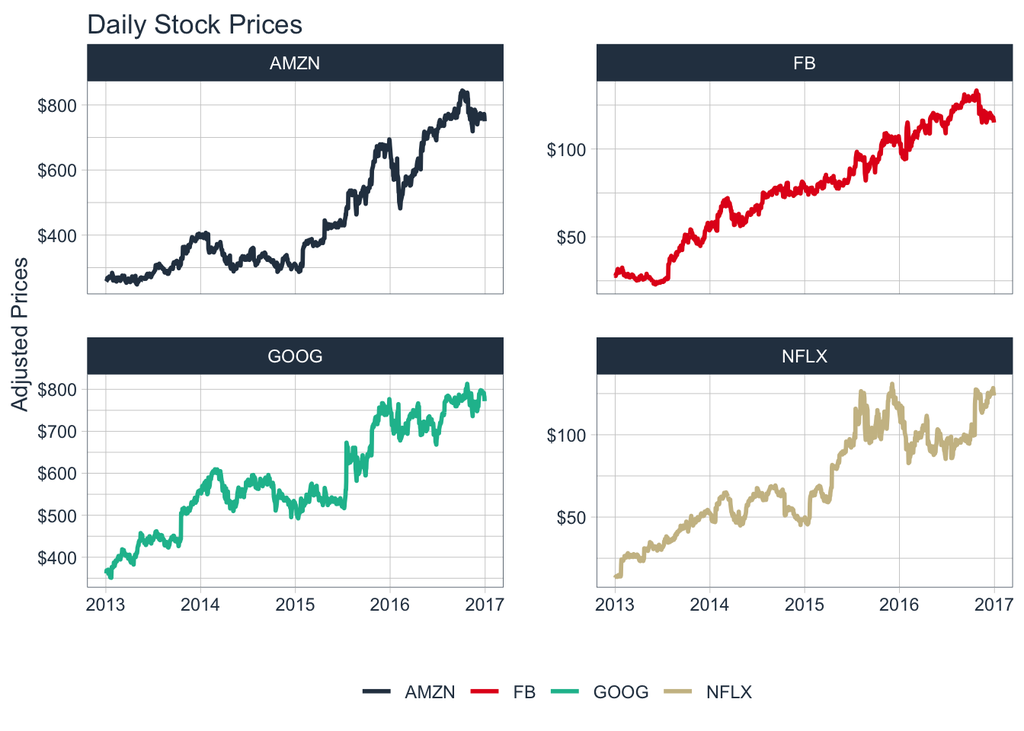

```r
FANG.plot.daily
```

### With Monthly Periodicity Aggregation

```r
FANG_monthly <- FANG %>%
    group_by(symbol) %>%
    tq_transmute(select     = adjusted,
                 mutate_fun = to.period,
                 period     = "months")

FANG.plot.daily <- FANG_monthly %>%
    ggplot(aes(x = date, y = adjusted, color = symbol)) +
    geom_line(size = 1) +
    labs(title = "Monthly Stock Prices",
         x = "", y = "Adjusted Prices", color = "") +
    facet_wrap(~ symbol, ncol = 2, scales = "free_y") +
    scale_y_continuous(labels = scales::dollar) +
    theme_tq() +
    scale_color_tq()
```

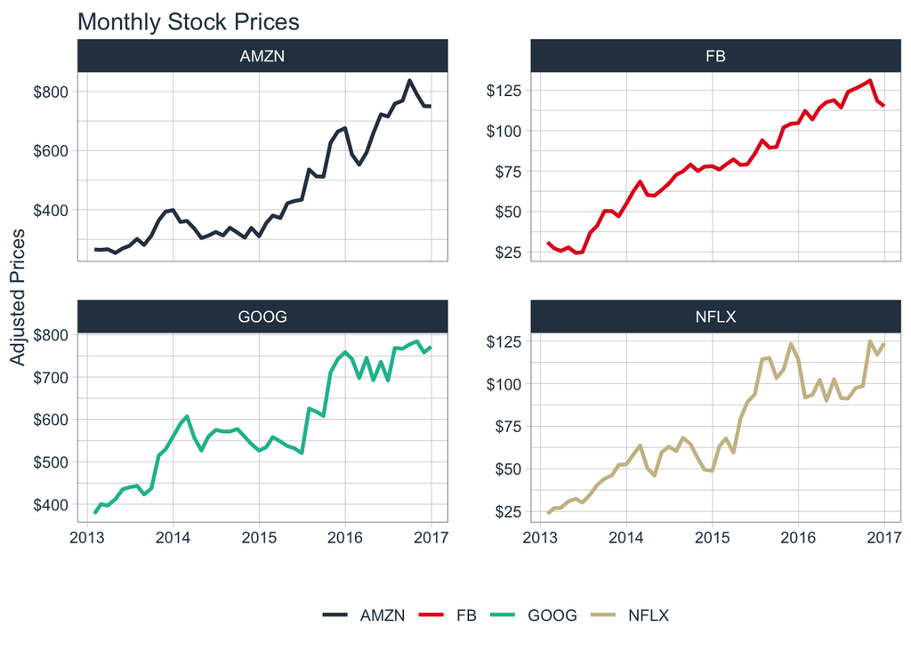

```r
FANG.plot.daily
```

# tq_performance() and tq_portfolio()

- Asset and portfolio performance analysis has a wide range of theories and methods for analyzing risk versus reward.
- **tq_performance()** implements these performance analysis functions in a tidy way
- **tq_performance()** converts investment returns into performance metrics.
- **tq_portfolio()** aggregates a group (or multiple groups) of asset returns into one or more portfolios.

Important concept: Performance is based on the statistical properties of returns, and as a result this function uses stock or portfolio returns as opposed to stock prices.

- We can use **tq_performance()** in the following form:

tq_performance(data, Ra, Rb = NULL, performance_fun, …)

- Where, Ra: asset returns, Rb: baseline returns

- performance_fun: 129 functions to analyze stock and portfolio return performance

- We can see **tq_performance_fun_options()** to investigate 129 functions.
- We only use two of these functions: **SharpeRatio** and **table.CAPM** we put each one of them for **performance_fun** argument.

```r
# Get returns for individual stock components grouped by symbol
(Ra <- FANG %>%
    group_by(symbol) %>%
    tq_transmute(adjusted, periodReturn,
                 period = "monthly", col_rename = "Ra"))
```

```
## # A tibble: 192 × 3
## # Groups:   symbol [4]
##    symbol date              Ra
##    <chr>  <date>         <dbl>
##  1 FB     2013-01-31  0.106
##  2 FB     2013-02-28 -0.120
##  3 FB     2013-03-28 -0.0613
##  4 FB     2013-04-30  0.0856
##  5 FB     2013-05-31 -0.123
##  6 FB     2013-06-28  0.0218
##  7 FB     2013-07-31  0.479
##  8 FB     2013-08-30  0.122
##  9 FB     2013-09-30  0.217
## 10 FB     2013-10-31 -0.000398
## # … with 182 more rows
```

```r
# Get returns for SP500 as baseline
(Rb <- "^GSPC" %>%
    tq_get(get  = "stock.prices",
           from = "2010-01-01",
           to   = "2015-12-31") %>%
    tq_transmute(adjusted, periodReturn,
                 period = "monthly", col_rename = "Rb"))
```

```
## # A tibble: 72 × 2
##    date            Rb
##    <date>       <dbl>
##  1 2010-01-29 -0.0522
##  2 2010-02-26  0.0285
##  3 2010-03-31  0.0588
##  4 2010-04-30  0.0148
##  5 2010-05-28 -0.0820
##  6 2010-06-30 -0.0539
##  7 2010-07-30  0.0688
##  8 2010-08-31 -0.0474
##  9 2010-09-30  0.0876
## 10 2010-10-29  0.0369
## # … with 62 more rows
```

```r
# Merge stock returns with baseline
(RaRb <- left_join(Ra, Rb, by = c("date" = "date")))
```

```
## # A tibble: 192 × 4
## # Groups:   symbol [4]
##    symbol date              Ra      Rb
##    <chr>  <date>         <dbl>   <dbl>
##  1 FB     2013-01-31  0.106     0.0504
##  2 FB     2013-02-28 -0.120     0.0111
##  3 FB     2013-03-28 -0.0613    0.0360
##  4 FB     2013-04-30  0.0856    0.0181
##  5 FB     2013-05-31 -0.123     0.0208
##  6 FB     2013-06-28  0.0218   -0.0150
##  7 FB     2013-07-31  0.479     0.0495
##  8 FB     2013-08-30  0.122    -0.0313
##  9 FB     2013-09-30  0.217     0.0297
## 10 FB     2013-10-31 -0.000398  0.0446
## # … with 182 more rows
```

## Sharpe Ratio

```r
RaRb %>%
    tq_performance(Ra = Ra, performance_fun = SharpeRatio, p = 0.95)
```

```
## # A tibble: 4 × 4
## # Groups:   symbol [4]
##   symbol `ESSharpe(Rf=0%,p=95%)` `StdDevSharpe(Rf=0%,p=95%)` `VaRSharpe(Rf=0%,p…
##   <chr>                    <dbl>                       <dbl>               <dbl>
## 1 FB                       0.193                       0.345               0.605
## 2 AMZN                     0.215                       0.314               0.265
## 3 NFLX                     0.199                       0.355               0.606
## 4 GOOG                     0.213                       0.296               0.310
```

## CAPM

```r
RaRb %>%
    tq_performance(Ra = Ra, Rb = Rb, performance_fun = table.CAPM)
```

```
## # A tibble: 4 × 13
## # Groups:   symbol [4]
##   symbol ActivePremium  Alpha AnnualizedAlpha  Beta `Beta-` `Beta+` Correlation
##   <chr>          <dbl>  <dbl>           <dbl> <dbl>   <dbl>   <dbl>       <dbl>
## 1 FB             0.431 0.034            0.493 0.846  0.819     3.00       0.234
## 2 AMZN           0.246 0.0144           0.187 1.46  -0.0442    2.04       0.524
## 3 NFLX           1.02  0.0632           1.09  1.35  -2.78      1.90       0.234
## 4 GOOG           0.142 0.0123           0.158 0.901 -0.247     1.56       0.451
## # … with 5 more variables: Correlationp-value <dbl>, InformationRatio <dbl>,
## #   R-squared <dbl>, TrackingError <dbl>, TreynorRatio <dbl>
```

The general workflow is shown in the diagram below. We talked about individual asset before. Now, We’ll step through the workflow of portfolio.

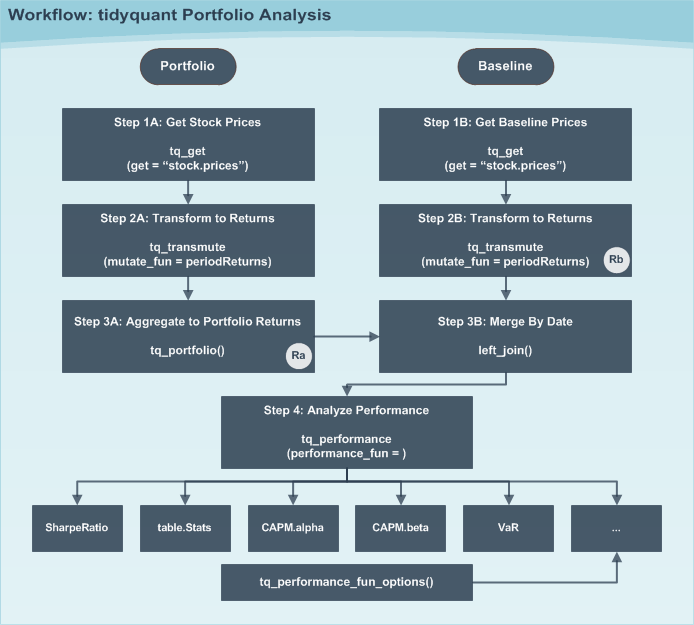

## Portfolios (Asset Groups)

- Portfolios are slightly more complicated because it is a groups of assets.
- We need to aggregate weighted returns.
- We use **tq_portfolio()**.

tq_portfolio(data, assets_col, returns_col, weights = NULL, col_rename = NULL, …)

We’ll use the weight vector, c(0.2, 0.3, 0.1, 0.4) for (FB, AMZN, NFLX, GOOG).

```r
wts <- c(0.2, 0.3, 0.1, 0.4) # (FB, AMZN, NFLX, GOOG)
portfolio_returns_monthly <- Ra %>%
    tq_portfolio(assets_col  = symbol,
                 returns_col = Ra,
                 weights     = wts,
                 col_rename  = "Ra")
portfolio_returns_monthly %>% head()
```

```
## # A tibble: 6 × 2
##   date             Ra
##   <date>        <dbl>
## 1 2013-01-31  0.128
## 2 2013-02-28  0.0194
## 3 2013-03-28 -0.0104
## 4 2013-04-30  0.0411
## 5 2013-05-31  0.0256
## 6 2013-06-28  0.00187
```

# R for Excel users

After tidyquant version 1.0.0, these features have been added.

- Pivot Tables in R
- VLOOKUP in R
- Summarizing “IFS” Functions
- 100 + New Excel Functions
- NEW API Integrations

## Excel Pivot Tables

For those that may have never used the Excel Pivot Table before, the process goes something like this.

- Start with a raw table in “long” format where each row is a unique observation
- Use the Excel Pivot Table dialog to position fields into Columns, Rows, and Summarized Values
- The Pivot Table is returned with the data summarized into columns and rows

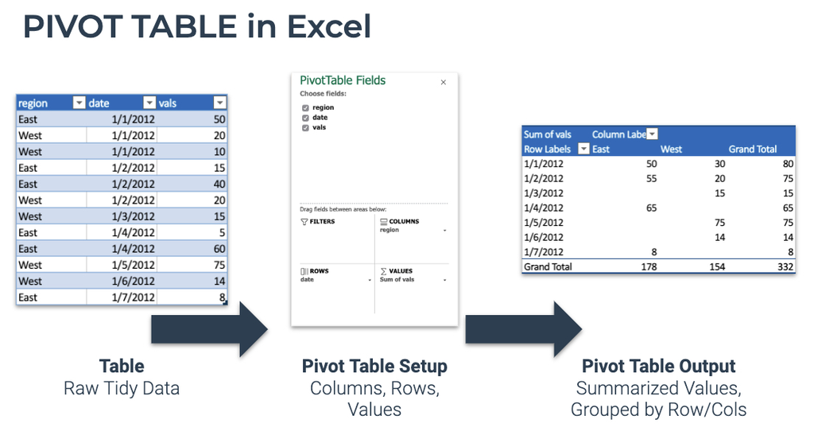

## R Pivot Table

In R with **pivot_table()**, we can do the same as Excel’s Pivot Table.

```r
FANG %>% head()
```

```
## # A tibble: 6 × 8
##   symbol date        open  high   low close    volume adjusted
##   <chr>  <date>     <dbl> <dbl> <dbl> <dbl>     <dbl>    <dbl>
## 1 FB     2013-01-02  27.4  28.2  27.4  28    69846400     28
## 2 FB     2013-01-03  27.9  28.5  27.6  27.8  63140600     27.8
## 3 FB     2013-01-04  28.0  28.9  27.8  28.8  72715400     28.8
## 4 FB     2013-01-07  28.7  29.8  28.6  29.4  83781800     29.4
## 5 FB     2013-01-08  29.5  29.6  28.9  29.1  45871300     29.1
## 6 FB     2013-01-09  29.7  30.6  29.5  30.6 104787700     30.6
```

- We can summarize this information with a Pivot Table using pivot_table(.rows, .columns, .values).
- First, we take a look to see if there are any missing (NA) values.
- The only trick is to use a ~ in front of any calculations.

```r
FANG %>%
    pivot_table(
        .columns = symbol,
        .values  = ~ SUM(is.na(adjusted))
    ) %>%
    kable()
```

| AMZN | FB | GOOG | NFLX |
| --- | --- | --- | --- |
| 0 | 0 | 0 | 0 |

- Next, we do some financial summarizations.
- First, take a look at percentage returns by year and quarter.
- This is easy to do by using stacked functions with the c() operator on .columns and .rows.

```r
FANG %>%
    pivot_table(
        .rows    = c(symbol, ~ QUARTER(date)),
        .columns = ~ YEAR(date),
        .values  = ~ (LAST(adjusted) - FIRST(adjusted)) / FIRST(adjusted)
    ) %>%
    kable(format = "markdown")
```

| symbol | QUARTER(date) | 2013 | 2014 | 2015 | 2016 |
| --- | --- | --- | --- | --- | --- |
| AMZN | 1 | 0.0356768 | -0.1547856 | 0.2060807 | -0.0680544 |
| AMZN | 2 | 0.0614656 | -0.0530919 | 0.1723923 | 0.1956892 |
| AMZN | 3 | 0.1082595 | -0.0299348 | 0.1703285 | 0.1538281 |
| AMZN | 4 | 0.2425300 | -0.0223965 | 0.2979913 | -0.1038196 |
| FB | 1 | -0.0864286 | 0.1010785 | 0.0480561 | 0.1162199 |
| FB | 2 | -0.0254603 | 0.0745768 | 0.0502020 | -0.0153369 |
| FB | 3 | 1.0245869 | 0.1613283 | 0.0344034 | 0.1233033 |
| FB | 4 | 0.0838954 | 0.0192031 | 0.1507422 | -0.1065466 |
| GOOG | 1 | 0.0980851 | 0.0017401 | 0.0441873 | 0.0041923 |
| GOOG | 2 | 0.0988279 | 0.0143170 | -0.0406450 | -0.0770892 |
| GOOG | 3 | -0.0134815 | -0.0091132 | 0.1659128 | 0.1116688 |
| GOOG | 4 | 0.2634837 | -0.0736798 | 0.2414403 | -0.0009578 |
| NFLX | 1 | 1.0571677 | -0.0297393 | 0.1941594 | -0.0702983 |
| NFLX | 2 | 0.1571014 | 0.2081494 | 0.5901917 | -0.1345316 |
| NFLX | 3 | 0.3786783 | -0.0463327 | 0.1027844 | 0.0194477 |
| NFLX | 4 | 0.1341568 | -0.2214904 | 0.0792602 | 0.2062750 |